# assignment

yinshu zhang

January 10, 2019

#### Declaimer

This is peer-review-assignment of “Practical Machine Learning” from Coursera.org

Github repo: https://github.com/yszhangit/ProAssignment11

## Background

Using devices such as Jawbone Up, Nike FuelBand, and Fitbit it is now possible to collect a large amount of data about personal activity relatively inexpensively. These type of devices are part of the quantified self movement - a group of enthusiasts who take measurements about themselves regularly to improve their health, to find patterns in their behavior, or because they are tech geeks. One thing that people regularly do is quantify how much of a particular activity they do, but they rarely quantify how well they do it. In this project, your goal will be to use data from accelerometers on the belt, forearm, arm, and dumbell of 6 participants. They were asked to perform barbell lifts correctly and incorrectly in 5 different ways

The goal is to build model to classify correct or incorrect way of exercise, or “how well they do it”. Their publish has more information about dataset http://web.archive.org/web/20161224072740/http:/groupware.les.inf.puc-rio.br/har

The data set can be downloaded from https://d396qusza40orc.cloudfront.net/predmachlearn/pml-training.csv for training and testing and https://d396qusza40orc.cloudfront.net/predmachlearn/pml-testing.csv as validation.

```r
data<-read.csv('https://d396qusza40orc.cloudfront.net/predmachlearn/pml-training.csv',na.strings = c("#DIV/0!","NA",""))
vali<-read.csv('https://d396qusza40orc.cloudfront.net/predmachlearn/pml-testing.csv',na.strings = c("#DIV/0!","NA",""))
#setwd('C:\Users\zhang\Desktop\R\ProAssignment11\ProAssignment11')
#data<-read.csv('./pml-training.csv',na.strings = c("#DIV/0!","NA",""))
#vali<-read.csv('./pml-testing.csv',na.strings = c("#DIV/0!","NA",""))
```

### cleanup

The first seven columns are timestamps and names, the published document stated the exercises are supervised by coach, we assume different person performed same way, in the end, we will need to predict “classe” base on detected movement data.

There are lot of missing data in both training and testing set, we have mark NA if the csv file content is NA, empty string, or #DIV/0!, it had made identify NA easier. Now we will remove the column is over 90% data is NA

```r
data<-data[, -(1:7)]
napct<-sapply(data, function(x) sum(is.na(x))/dim(data)[1])
data <- data[,napct < 0.9]
vali<-vali[, -(1:7)]
napct<-sapply(vali, function(x) sum(is.na(x))/dim(vali)[1])
vali <- vali[,napct < 0.9]
```

The result data is 19622 by 53 data frame.

### preProcess

```r
dummyVars(classe~., data=data)
```

```
## Dummy Variable Object
##
## Formula: classe ~ .
## 53 variables, 1 factors
## Variables and levels will be separated by '.'
## A less than full rank encoding is used
```

```r
nearZeroVar(vali)
```

```
## integer(0)
```

```r
findLinearCombos(data[,-53])
```

```
## $linearCombos
## list()
##
## $remove
## NULL
```

```r
cor90<-findCorrelation(cor(data[,-53]))
cor90
```

```
## [1] 10  1  9  8 31 33 18
```

Check if preProcessing is needed. from the output of above block, there’s no near zero data, no need to create dummy variables, no high linear depenendent columns.

there are high correlation columns, however, after testing, removing those columns didnt help improve the accuracy, check github code for reproducing comparsion.

### Split

consider the data size, we will use 75% for training data and 25% for testing.

```r
ind_train<-createDataPartition(data$classe, p=0.75, list=F)
training<-data[ind_train,]
testing<-data[-ind_train,]
```

### Train the models

```r
# init parallel processing
cl <- makeCluster(detectCores() -1)
registerDoParallel(cl)
# non repeating cross validation with 5 fold
fitControl <- trainControl(method="cv", number = 5, allowParallel = T)
#
set.seed(312)
mod_rp<-train(classe ~ ., data=training, method="rpart", trControl = fitControl)
# random forest
set.seed(312)
mod_r<-train(classe ~ ., data=training, method="rf", trControl = fitControl)
set.seed(312)
mod_rpca<-train(classe ~ ., data=training, method="rf", trControl = fitControl, preProcess="pca")
# boosting
set.seed(312)
mod_b <- train(classe ~ ., data=training, method="gbm", verbose=F, trControl=fitControl)

stopCluster(cl)
registerDoSEQ()
```

We will experiment four different methods, simple tree using recursive partition, random forest, random forest with PCA preprocessing, and boosting. In order to imporve training performance, enable parallelism in fitControl.

### Model accuracy

#### recursive partition

```r
pred_rp <- predict(mod_rp, testing)
confusionMatrix(testing$classe, pred_rp)$overall
```

```
##       Accuracy          Kappa  AccuracyLower  AccuracyUpper   AccuracyNull
##      0.4900082      0.3332594      0.4759244      0.5041038      0.5220228
## AccuracyPValue  McnemarPValue
##      0.9999966            NaN
```

using rpart without any tuning is worse than toss a coin.

#### Random forest

```r
pred_r <- predict(mod_r, testing)
oose<-sum(pred_r != testing$classe)/dim(testing)[1]
cmx<-confusionMatrix(testing$classe, pred_r)
cmx$overall
```

```
##       Accuracy          Kappa  AccuracyLower  AccuracyUpper   AccuracyNull
##      0.9991843      0.9989683      0.9979129      0.9997777      0.2848695
## AccuracyPValue  McnemarPValue
##      0.0000000            NaN
```

Random forest results very good accuracy at 0.9991843, out of sample error rate 8.156606910^{-4}, as mentioned earlier, there are high correalted predictor, we try PCA preProcessing with same random forest setup, result below showed preProcess didnt gain accuracy.

```r
pred_rpca <- predict(mod_rpca, testing)
oose<-sum(pred_rpca != testing$classe)/dim(testing)[1]
cmx<-confusionMatrix(testing$classe, pred_rpca)
cmx$overall
```

```
##       Accuracy          Kappa  AccuracyLower  AccuracyUpper   AccuracyNull
##      0.9959217      0.9948413      0.9937084      0.9975071      0.2848695
## AccuracyPValue  McnemarPValue
##      0.0000000            NaN
```

Accuracy: 0.9959217

Out of sample error rate: 0.0040783

#### Boosting

```r
pred_b <- predict(mod_b, testing)
oose<-sum(pred_b != testing$classe)/dim(testing)[1]
cmx<-confusionMatrix(testing$classe, pred_b)
cmx$overall
```

```
##       Accuracy          Kappa  AccuracyLower  AccuracyUpper   AccuracyNull
##   9.708401e-01   9.631034e-01   9.657397e-01   9.753692e-01   2.875204e-01
## AccuracyPValue  McnemarPValue
##   0.000000e+00   6.092180e-06
```

Accuracy: 0.9708401

Out of sample error rate: 0.0291599

Boosting has good result as while, not as accurate as random forest.

### compare the models

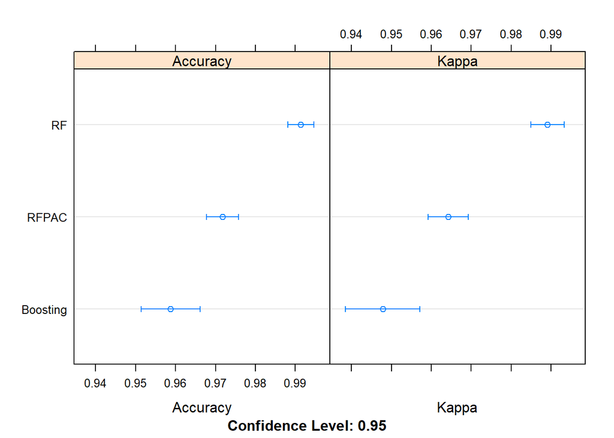

```r
comparsion <- resamples(list(RF=mod_r, RFPAC=mod_rpca, Boosting=mod_b))
dotplot(comparsion)
```

Visalized comparsion between models

Conclusion: All model execpt “rpart” has good enough accuracy, random forest without pre-processing come out as best model.

## validation

Apply best model to validation

```r
predict(mod_r, vali)
```

```
##  [1] B A B A A E D B A A B C B A E E A B B B
## Levels: A B C D E
```